# arctraining slides – swd3

## SWD3

### Software development practices for Research

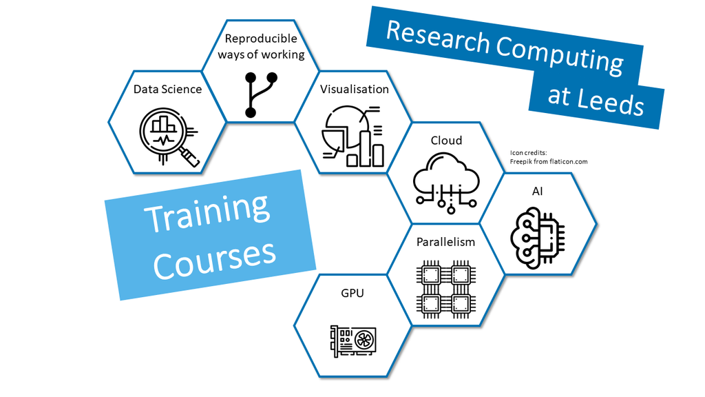

## Research Computing [Team](https://arc.leeds.ac.uk/about/team/) and Service

- Here to support research(ers)
  - Provide training
  - Support users of Grid and Cloud Computing platforms
  - Provide consultancy
    - To develop project proposals
    - To help recruit people with specialist skills
    - Working directly on research projects
- For details please see our [Website](https://arc.leeds.ac.uk/)
- [Contact us via the IT Service Desk](https://bit.ly/arc-help)

## Useful Links

- [GitHub Project Demo](https://github.com/ARCTraining/swd3-demo)
- [Alan Turing Institute - Research Software Engineering Course Material](https://alan-turing-institute.github.io/rse-course/html/index.html)

## Software Development Life Cycle (SDLC)

[figure not shown]

## SDLC

- Ideation
- Requirements
- Design
- Development
- Test
- Deployment
- Maintenance

What are we going to do?

- Brainstorming
- Research

[figure not shown]

How are we going to do it?

Some topics to help define requirements include:

- final goal
- project scope (how to reach the final goal)
- what is feasible (and how)
- what is priority
- what resources are available
- deadlines
- potential risks

Warning: Each person involved in the project may have a different need.

[figure not shown]

What is the software architecture?

When designing software, the object-oriented approach is a common programming paradigm.

Object-oriented components:

- **Classes:** A user-defined type
- **Object instances:** A particular object instantiated from a class.
- **Methods:** A function which is “built in” to a class
- **Constructor:** A special method called when instantiating a new object

Some principles: abstraction, encapsulation, decomposition, generalisation

[figure not shown]

See more:

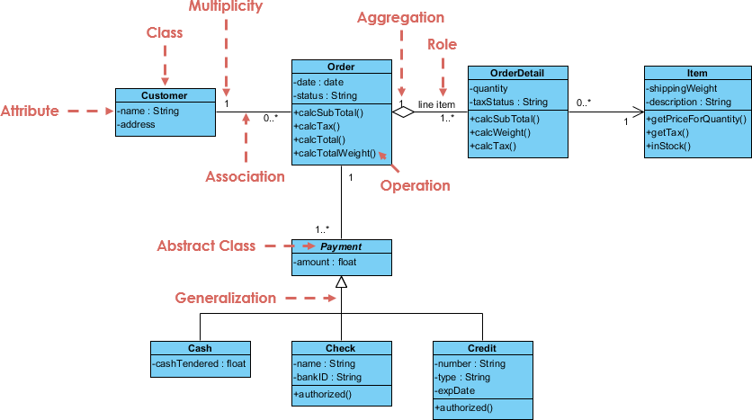

Is this where the fun begins?

Take your time

[figure not shown]

Development is usually the most time consuming step in a Software Development Life Cycle.

Is this software good?

In this step, errors and failures are identified by exposing the code to an environment similar to the end-user experience.

There are several types of testing, some examples include:

- **Unit testing:** are all components working?
- **Integration testing:** are all components working when fitted together?
- **Performance testing:** how does the software perform against different workloads? It is fast? Stable?
- **Functional testing:** is the software aligned with Software Requirement Specification?

[figure not shown]

Can other people use my code?

You can use platforms like [GitHub](https://github.com/) to release your software.

- The **functionality** of the software is linked to **several specifications** related to the operating system and versions of packages and other software related to the project.
- **Listing these specifications will help** others to replicate the environment in which the software was developed.

[figure not shown]

Is it over?

We can classify maintenance into a few categories:

- **Corrective:** fix reported errors/failures.
- **Preventive:** regular checks and fixes.
- **Perfective:** optimize implemented features, adding new features.
- **Adaptive:** keep the software updated according to changes external to the project (new programming language version, new regulation, etc.).

[figure not shown]

## Basic Structure Suggestion

```bash
# The most basic structure for a code project should look like:
my-model
├── README.md
├── requirements.txt
├── src                <- Source code for this project
└── tests              <- Test code for this project
```

- Readme
- Requirements
- Is a guide that gives users a detailed description of a project you have worked on
- It is the first file a person will see when they encounter your project, so it should be fairly brief but detailed.
- See how to write a good README file in this [`freecodecamp` post](https://www.freecodecamp.org/news/how-to-write-a-good-readme-file/).
- Text information about all the necessary additional libraries, modules, and packages.
- This can be replaced by files like: [`environment.yml`](https://conda.io/projects/conda/en/latest/user-guide/tasks/manage-environments.html#creating-an-environment-from-an-environment-yml-file), [`pyproject.toml`](https://packaging.python.org/en/latest/tutorials/packaging-projects/#creating-pyproject-toml), [`setup.py`](https://www.pythonforthelab.com/blog/how-create-setup-file-your-project/).

## Advanced Project Structure

Template based on [mkrapp/cookiecutter-reproducible-science github](https://github.com/mkrapp/cookiecutter-reproducible-science)

```bash
.
├── AUTHORS.md
├── LICENSE
├── README.md
├── bin                <- Your compiled model code can be stored here (not tracked by git)
├── config             <- Configuration files, e.g., for doxygen or for your model if needed
├── data
│   ├── external       <- Data from third party sources.
│   ├── interim        <- Intermediate data that has been transformed.
│   ├── processed      <- The final, canonical data sets for modeling.
│   └── raw            <- The original, immutable data dump.
├── docs               <- Documentation, e.g., doxygen or scientific papers (not tracked by git)
├── notebooks          <- Ipython or R notebooks
├── reports            <- For a manuscript source, e.g., LaTeX, Markdown, etc., or any project reports
│   └── figures        <- Figures for the manuscript or reports
├── src                <- Source code for this project
│   ├── data           <- scripts and programs to process data
│   ├── external       <- Any external source code, e.g., pull other git projects, or external libraries
│   ├── models         <- Source code for your own model
│   ├── tools          <- Any helper scripts go here
│   └── visualization  <- Scripts for visualisation of your results, e.g., matplotlib, ggplot2 related.
└── tests              <- Test code for this project
```

## Virtual Environments

If application A needs version 1.0 of a particular module but application B needs version 2.0, then the requirements are in conflict and installing either version 1.0 or 2.0 will leave one application unable to run.

The solution for this problem is to create a virtual environment, a self-contained directory tree that contains installation for particular versions of software/packages.

### Conda

- [Conda](https://docs.conda.io/en/latest/) is an open source package management system and environment management system that runs on Windows, macOS, and Linux.
- It offers dependency and environment management for any language—Python, R, Ruby, Lua, Scala, Java, JavaScript, C/ C++, Fortran, and more.
- Easy user install via [Anaconda](https://www.anaconda.com/download).

## Code formatting

```python
# myscript.py:
x = {  'a':37,'b':42,
'c':927}
y = 'hello '+       'world'
class foo  (     object  ):
   def f    (self   ):
       return       y **2
   def g(self, x :int,
       y : int=42
       ) -> int:
       return x--y
def f  (   a ) :
   return      37+-a[42-a :  y*3]
```

## Coding conventions

If your language or project has a standard policy, use that. For example:

- Python: [PEP8](https://www.python.org/dev/peps/pep-0008/)
- R: [Google’s guide for R](https://google.github.io/styleguide/Rguide.xml), [tidyverse style guide](https://style.tidyverse.org/)
- C++: [Google’s style guide](https://google.github.io/styleguide/cppguide.html)
- Julia: [Official style guide](https://docs.julialang.org/en/v1/manual/style-guide/index.html)

## Linters

Linters are automated tools which enforce coding conventions and check for common mistakes. For example:

- Python:
  - [flake8](https://flake8.pycqa.org/en/latest/index.html) (flags any syntax/style errors)
  - [black](https://black.readthedocs.io/) (enforces the style)
  - [isort](https://pycqa.github.io/isort/) (“Sorts” imports alphabetically in groups)

## Example: Flake8 Linter

```bash
$ conda install flake8
$ flake8 myscript.py
myscript.py:2:6: E201 whitespace after '{'
myscript.py:2:11: E231 missing whitespace after ':'
myscript.py:2:14: E231 missing whitespace after ','
myscript.py:2:18: E231 missing whitespace after ':'
myscript.py:3:1: E128 continuation line under-indented for visual indent
myscript.py:3:4: E231 missing whitespace after ':'
myscript.py:4:13: E225 missing whitespace around operator
myscript.py:4:14: E222 multiple spaces after operator
myscript.py:5:1: E302 expected 2 blank lines, found 0
myscript.py:5:13: E201 whitespace after '('
myscript.py:5:25: E202 whitespace before ')'
myscript.py:6:4: E111 indentation is not a multiple of 4
myscript.py:6:9: E211 whitespace before '('
myscript.py:6:20: E202 whitespace before ')'
myscript.py:7:8: E111 indentation is not a multiple of 4
myscript.py:7:14: E271 multiple spaces after keyword
myscript.py:7:25: E225 missing whitespace around operator
myscript.py:8:4: E301 expected 1 blank line, found 0
myscript.py:8:4: E111 indentation is not a multiple of 4
myscript.py:8:17: E203 whitespace before ':'
myscript.py:8:18: E231 missing whitespace after ':'
myscript.py:9:8: E128 continuation line under-indented for visual indent
myscript.py:9:9: E203 whitespace before ':'
myscript.py:9:15: E252 missing whitespace around parameter equals
myscript.py:9:16: E252 missing whitespace around parameter equals
myscript.py:10:8: E124 closing bracket does not match visual indentation
myscript.py:10:8: E125 continuation line with same indent as next logical line
myscript.py:11:8: E111 indentation is not a multiple of 4
myscript.py:12:1: E302 expected 2 blank lines, found 0
myscript.py:12:6: E211 whitespace before '('
myscript.py:12:9: E201 whitespace after '('
myscript.py:12:13: E202 whitespace before ')'
myscript.py:12:15: E203 whitespace before ':'
myscript.py:13:4: E111 indentation is not a multiple of 4
myscript.py:13:10: E271 multiple spaces after keyword
myscript.py:13:26: E203 whitespace before ':'
myscript.py:13:34: W291 trailing whitespace
```

## Example: Black Code Formatter

Install and run Black

```bash
$ conda install black
$ black myscript.py
```

Check the file!

```python
# myscript.py:
x = {"a": 37, "b": 42, "c": 927}
y = "hello " + "world"


class foo(object):
    def f(self):
        return y**2

    def g(self, x: int, y: int = 42) -> int:
        return x - -y


def f(a):
    return 37 + -a[42 - a : y * 3]
```

## IDE

Using an Integrated development environment (IDE) will certainly save you time, but the advantages of using an IDE go beyond that. Below are some IDE advantages

1. Syntax highlighting
2. Text autocompletion
3. Refactoring options
4. Easily Importing libraries
5. Build, compile, or run

### Visual Studio Code

To install VS Code follow the instructions [here](https://code.visualstudio.com/).

## VSC Example: automatically using black

**Configure VSC to use Black**: Code (or File) > Preferences > Settings

- Search for `python formatting provider` and choose `black`
- Search for `format on save` and check the box to enable

**Select interpreter**: View > `Command Palette..` (or `Ctrl+Shift+P`)

- Search for `Python: Select Interpreter`
- Choose the correct environment

Now the Black package is going to fix your codes layout every time you save a code file.

## Test-driven development

**Example**, suppose we need to find the result of a number divided by another number:

- Naive solution
- TDD solution
- Write a function a_div_b.
- Call it interactively on two or three different inputs.
- If it produces the wrong answer, fix the function and re-run that test.

This clearly works — after all, thousands of scientists are doing it right now — but there’s a better way

- Write a short function for each test.
- Write a `a_div_b` function that should pass those tests.
- If `a_div_b` produces any wrong answers, fix it and re-run the test functions.

Writing the tests before writing the function they exercise is called **test-driven development (TDD)**. Its advocates believe it produces better code faster because:

- If people write tests after writing the thing to be tested, they are subject to confirmation bias, i.e., they subconsciously write tests to show that their code is correct, rather than to find errors.
- Writing tests helps programmers figure out what the function is actually supposed to do.

## Possible tests: `a_div_b` example

Let’s think in all possible scenarios for this problem and how we could test them.

- Bigger by smaller
- Smaller by bigger
- Negative numbers
- Using `4` and `2`, the answer should be `2`.

```python
assert a_div_b(4, 2) == 2
```

- Or… the answer should be `larger` than `1`.

```python
assert a_div_b(8, 7) > 1
```

- Using `2` and `4`, the answer should be `0.5`.

```python
assert a_div_b(2, 4) == 0.5
```

- Or… the answer should be `smaller` than `1`.

```python
assert a_div_b(7, 8) < 1
```

- Using `-4` and `-2`, the answer should be `2`.

```python
assert a_div_b(-4, -2) == 2
```

- Or… the answer should be `positive`.

```python
assert a_div_b(-4, -2) > 0
```

## Bringing it all together

### The Hypotenuse Problem

Calculating the hypotenuse

$$c = \sqrt{a^2 + b^2}$$

General Design

- 1 squared function
- 1 sum function
- 1 square root function
- 1 hypotenuse function that uses the other functions

## Workflow

1. Install Git, Anaconda, VScode
2. Create a GitHub repository + Licence + .gitignore + Readme
3. Setup GH Action for testing (Python Application)
4. Clone GH repository in local machine
5. Create project structure (source and test folders)
6. Setup tests (start with `test_`)
7. Develop code
8. Add docstring (you can use `autoDocstring - Python Docstring Generator on VS Code`)
9. Lint code and tests
10. Push to github
11. EXTRA: Create Sphinx documentation
12. EXTRA: Setup file and local install
13. EXTRA: GH Release

## Extra: Sphinx documentation

- Create docstring for every function
- Install `sphinx`
- Start the basic structure using: `$ sphinx-quickstart docs`
- Use the apidoc to get docstrings: `$ sphinx-apidoc -o docs .`
- Edit files:
- `conf.py`
- `index.rst`
- `dependencies.rst`
- `usage.rst`
- `functions.rst`
- add extentions: `'sphinx.ext.todo', 'sphinx.ext.viewcode', 'sphinx.ext.autodoc'`.
- change theme: `sphinx_rtd_theme`
- add the `src` (change the folder name as necessary!) folder as path:

```python
 import os
 import sys
 sys.path.insert(0, os.path.abspath('../src'))
```

Add extra files after `Contents`

```
.. toctree::
   :maxdepth: 2
   :caption: Contents:

   dependencies
   usage
   functions
```

List all your dependencies:

```
Dependencies
============

- python
- pytest
- flake8
- black
- sphinx
```

Explain how to use your software

```
Usage Guide
============

To start working with this repository you need to clone it onto your local
machine: ::

    $ git clone https://github.com/...


Next ...
```

Create a function file with the following:

```
API reference
=============

.. automodule:: calc
   :members:
   :undoc-members:
   :show-inheritance:
```

## Extra: documentation Action

Create a new GH action to create a nice website for your documentation.

- The action is available [here](https://github.com/patricia-ternes/hypot-2023/blob/main/.github/workflows/documentation.yml)
- You may need update GH Actions permissions to allow `write`
- After a successful documentation action, you need to select `gh-pages` branch to activate your website

## Extra: Setup file

Create a `setup.py` file like:

```python
import setuptools

with open("README.md", "r") as fh:
    long_description = fh.read()

setuptools.setup(
    name="hypot",
    version="0.1.0",
    author="Patricia Ternes",
    author_email="p.ternesdallagnollo@leeds.ac.uk",
    description="The hypot SWD3 demo package",
    packages=setuptools.find_packages(),
    classifiers=[
        "Programming Language :: Python :: 3.9",
        "Intended Audience :: Science/Research/Learning",
    ],
    python_requires=">=3.9",
)
```

## Local Installation

**Install:** install the hypot package into the environment using:

```bash
$ python setup.py install
```

**Usage:** if you want to create a personalised script, you can import the hypot modules as follows:

```python
from hypot.calc import squared, addition, sqroot
```

**Remove:** If you want to remove your package, use pip:

```bash
$ pip uninstall hypot
```

## Release

Release in GitHub are based in tags with the following structure:

`v0.5.2`

| Change | Release | Example |
| --- | --- | --- |
| Major | Breaking | 0 |
| Minor | Feature | 5 |
| Patch | Fix | 2 |

[Research IT Website](https://arc.leeds.ac.uk/) | [Research IT Query](https://bit.ly/arc-help) | [Courses Material](https://arctraining.github.io/)